# Donor Metadata: Exploratory Analysis

2024-02-16 16:41:25

# Load libraries

```r
library(stringr)
library(ggplot2)
library(viridis)
```

# Define functions

```r
swPval <- function(x) {
  shapiro.test(x)$p.value
}
```

# Load data

Read csv file:

```r
donors <- read.csv("../data/donor_metadata.csv", row.names=1, na.strings="NA")
```

Create variable to represent group:

```r
grp <- c(rep("P", 20),rep("C", 20))
grpColor <- ifelse(grp=="C", "blue", "red")
grpPch <- ifelse(grp=="C", 15, 16)
```

Set datatype of columns in donors data.frame:

```r
donors$Dementia...cognitive.impairment <- as.factor(donors$Dementia...cognitive.impairment)
donors$Depression <- factor(donors$Depression)
donors$Memory.problems <- as.factor(donors$Memory.problems)
donors$Sleep.disturbance <- as.factor(donors$Sleep.disturbance)
donors$Aggression <- as.factor(donors$Aggression)
donors$Hallucinations <- as.factor(donors$Hallucinations)
donors$Psychotic.symptoms <- as.factor(donors$Psychotic.symptoms)
donors$LB.disease.type <- factor(donors$LB.disease.type)
donors$LB.Braak.stage <- factor(donors$LB.Braak.stage, ordered=TRUE)
donors$SN.depigmentation <- factor(donors$SN.depigmentation, ordered=TRUE)
donors$Amyloid.pathology <- factor(donors$Amyloid.pathology, ordered=TRUE)
donors$Tau.pathology <- factor(donors$Tau.pathology, ordered=TRUE)
donors$Vessel.disease...CAA <- factor(donors$Vessel.disease...CAA, ordered=TRUE)
donors$Age <- as.numeric(donors$Age)
donors$PD.duration <- as.numeric(donors$PD.duration)
donors$Gender <- as.factor(donors$Gender)
```

# Types of variables

The variables in the donor metadata can be broadly divided into two types: categorical (discrete/qualitative) and continuous (quantitative). The categorical variables can be further divided into three subtypes: nominal, dichotomous and ordinal. These are described below.

## Categorical variables

### Nominal

Nominal variables have two or more categories, but do not have an intrinsic order.

- LB disease type

### Dichotomous

Dichotomous variables are nominal variables with only two categories.

- Dementia / cognitive impairment
- Depression
- Sleep disturbance
- Aggression
- Hallucinations
- Psychotic symptoms
- Gender

### Ordinal

Ordinal variables have two or more categories that can be ordered or ranked.

- LB Braak stage
- SN depigmentation
- Amyloid pathology
- Tau pathology
- Vessel disease / CAA

## Continuous variables

- Age
- PD duration

# Differences between PD and control groups

## Categorical variables

### LB disease type

This variable is only applicable to the PD group. There are no data for the control group.

```r
df <- data.frame(table(donors$LB.disease.type[grp=="P"]))
names(df) <- c("Disease Type", "Count")
knitr::kable(df)
```

| Disease Type | Count |
| --- | --- |
| brainstem | 1 |
| limbic | 4 |
| neocortical | 15 |

### Dementia / cognitive impairment

```r
knitr::kable(table(donors$Dementia...cognitive.impairment, grp))
```

|  | C | P |
| --- | --- | --- |
| 0 | 19 | 4 |
| 1 | 1 | 14 |

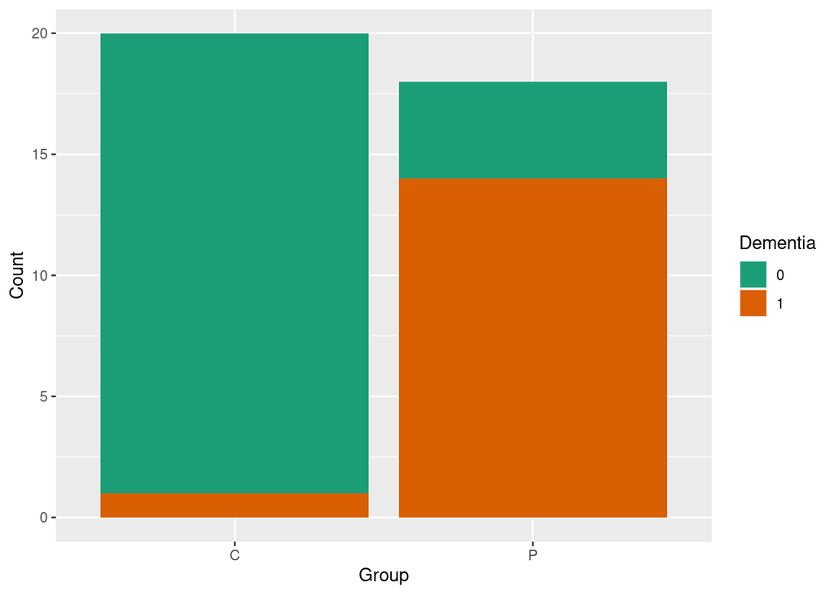

```r
df <- data.frame(table(donors$Dementia...cognitive.impairment, grp))
names(df) <- c("Dementia", "Group", "Count")

ggplot(data=df, aes(x=Group, y=Count, fill=Dementia)) +
  geom_bar(stat="identity") +
  scale_fill_brewer(palette = "Dark2")
```

Fisher’s exact test to compare groups:

```r
fisher.test(donors$Dementia...cognitive.impairment, grp)
```

```
##
##  Fisher's Exact Test for Count Data
##
## data:  donors$Dementia...cognitive.impairment and grp
## p-value = 5.011e-06
## alternative hypothesis: true odds ratio is not equal to 1
## 95 percent confidence interval:
##     5.887243 2887.782709
## sample estimates:
## odds ratio
##   55.88708
```

### Depression

```r
knitr::kable(table(donors$Depression, grp))
```

|  | C | P |
| --- | --- | --- |
| 0 | 18 | 8 |
| 1 | 2 | 10 |

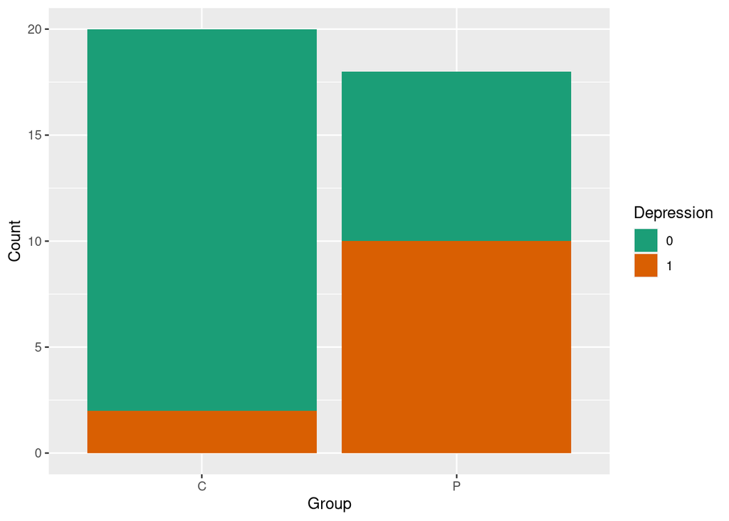

```r
df <- data.frame(table(donors$Depression, grp))
names(df) <- c("Depression", "Group", "Count")

ggplot(data=df, aes(x=Group, y=Count, fill=Depression)) +
  geom_bar(stat="identity") +
  scale_fill_brewer(palette = "Dark2")
```

Fisher’s exact test to compare groups:

```r
fisher.test(donors$Depression, grp)
```

```
##
##  Fisher's Exact Test for Count Data
##
## data:  donors$Depression and grp
## p-value = 0.004476
## alternative hypothesis: true odds ratio is not equal to 1
## 95 percent confidence interval:
##    1.687115 119.911262
## sample estimates:
## odds ratio
##   10.46245
```

### Sleep disturbance

```r
knitr::kable(table(donors$Sleep.disturbance, grp))
```

|  | C | P |
| --- | --- | --- |
| 0 | 19 | 3 |
| 1 | 1 | 15 |

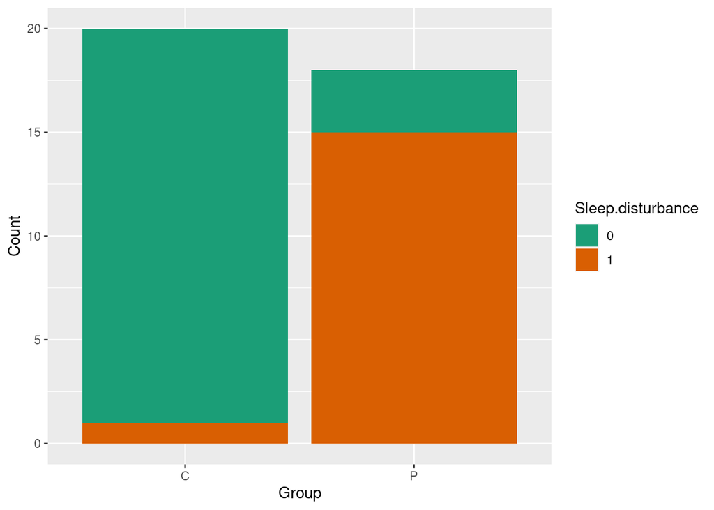

```r
df <- data.frame(table(donors$Sleep.disturbance, grp))
names(df) <- c("Sleep.disturbance", "Group", "Count")

ggplot(data=df, aes(x=Group, y=Count, fill=Sleep.disturbance)) +
  geom_bar(stat="identity") +
  scale_fill_brewer(palette = "Dark2")
```

Fisher’s exact test to compare groups:

```r
fisher.test(donors$Sleep.disturbance, grp)
```

```
##
##  Fisher's Exact Test for Count Data
##
## data:  donors$Sleep.disturbance and grp
## p-value = 9.585e-07
## alternative hypothesis: true odds ratio is not equal to 1
## 95 percent confidence interval:
##     7.626068 4056.561405
## sample estimates:
## odds ratio
##   76.17329
```

### Aggression

```r
knitr::kable(table(donors$Aggression, grp))
```

|  | C | P |
| --- | --- | --- |
| 0 | 20 | 11 |
| 1 | 0 | 7 |

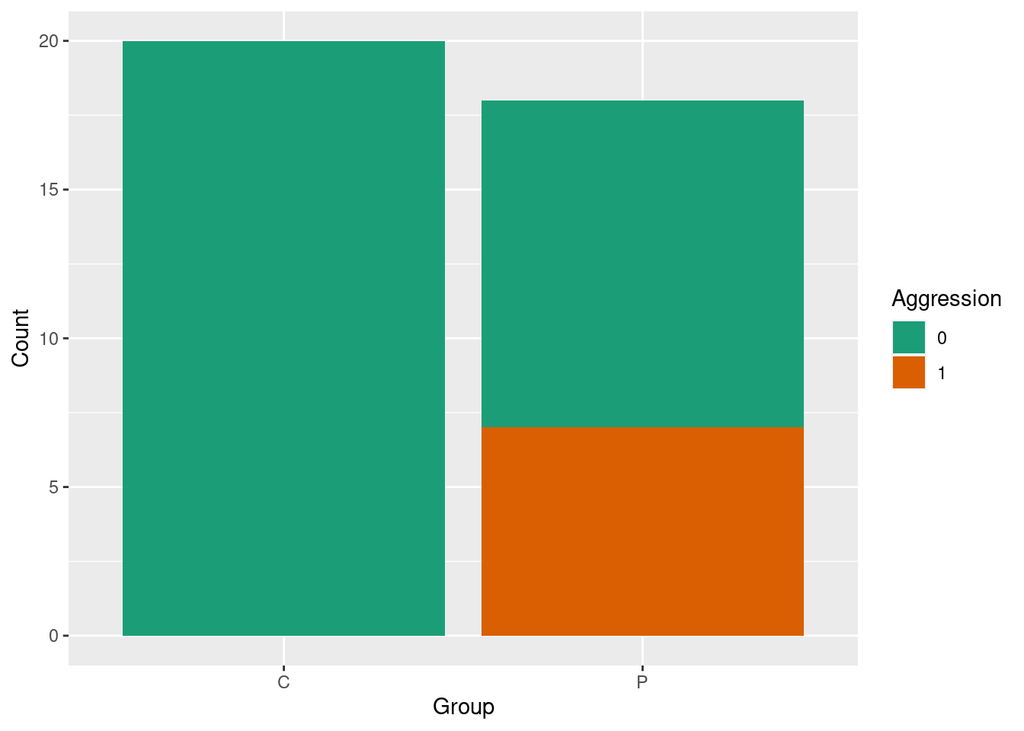

```r
df <- data.frame(table(donors$Aggression, grp))
names(df) <- c("Aggression", "Group", "Count")

ggplot(data=df, aes(x=Group, y=Count, fill=Aggression)) +
  geom_bar(stat="identity") +
  scale_fill_brewer(palette = "Dark2")
```

Fisher’s exact test to compare groups:

```r
fisher.test(donors$Aggression, grp)
```

```
##
##  Fisher's Exact Test for Count Data
##
## data:  donors$Aggression and grp
## p-value = 0.002522
## alternative hypothesis: true odds ratio is not equal to 1
## 95 percent confidence interval:
##  2.06909     Inf
## sample estimates:
## odds ratio
##        Inf
```

### Hallucinations

```r
knitr::kable(table(donors$Hallucinations, grp))
```

|  | C | P |
| --- | --- | --- |
| 0 | 20 | 4 |
| 1 | 0 | 14 |

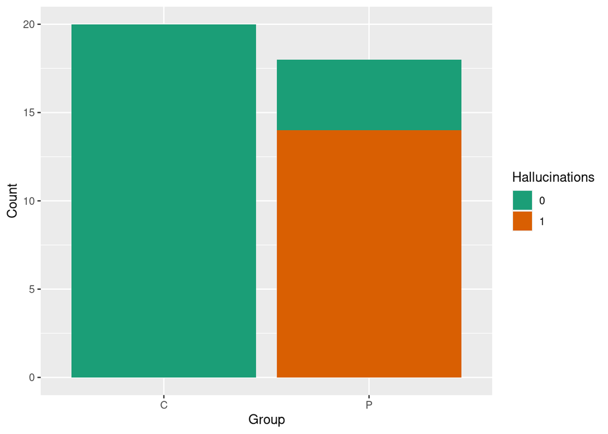

```r
df <- data.frame(table(donors$Hallucinations, grp))
names(df) <- c("Hallucinations", "Group", "Count")

ggplot(data=df, aes(x=Group, y=Count, fill=Hallucinations)) +
  geom_bar(stat="identity") +
  scale_fill_brewer(palette = "Dark2")
```

Fisher’s exact test to compare groups:

```r
fisher.test(donors$Hallucinations, grp)
```

```
##
##  Fisher's Exact Test for Count Data
##
## data:  donors$Hallucinations and grp
## p-value = 3.165e-07
## alternative hypothesis: true odds ratio is not equal to 1
## 95 percent confidence interval:
##  10.00115      Inf
## sample estimates:
## odds ratio
##        Inf
```

### Psychotic symptoms

```r
knitr::kable(table(donors$Psychotic.symptoms, grp))
```

|  | C | P |
| --- | --- | --- |
| 0 | 20 | 13 |
| 1 | 0 | 5 |

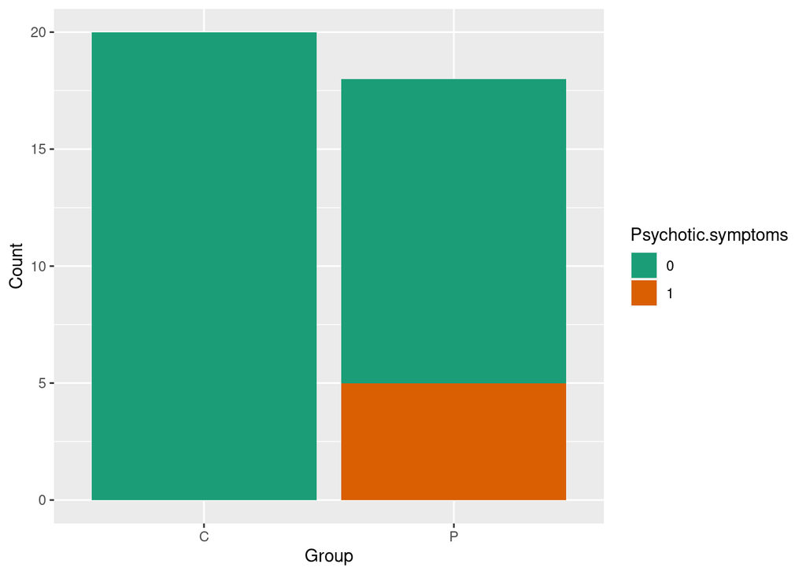

```r
df <- data.frame(table(donors$Psychotic.symptoms, grp))
names(df) <- c("Psychotic.symptoms", "Group", "Count")

ggplot(data=df, aes(x=Group, y=Count, fill=Psychotic.symptoms)) +
  geom_bar(stat="identity") +
  scale_fill_brewer(palette = "Dark2")
```

Fisher’s exact test to compare groups:

```r
fisher.test(donors$Psychotic.symptoms, grp)
```

```
##
##  Fisher's Exact Test for Count Data
##
## data:  donors$Psychotic.symptoms and grp
## p-value = 0.01707
## alternative hypothesis: true odds ratio is not equal to 1
## 95 percent confidence interval:
##  1.161503      Inf
## sample estimates:
## odds ratio
##        Inf
```

### Gender

```r
knitr::kable(table(donors$Gender, grp))
```

|  | C | P |
| --- | --- | --- |
| F | 12 | 5 |
| M | 8 | 15 |

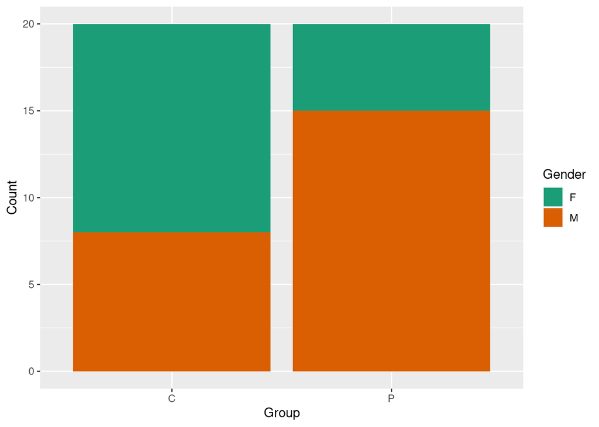

```r
df <- data.frame(table(donors$Gender, grp))
names(df) <- c("Gender", "Group", "Count")

ggplot(data=df, aes(x=Group, y=Count, fill=Gender)) +
  geom_bar(stat="identity") +
  scale_fill_brewer(palette = "Dark2")
```

Fisher’s exact test to compare groups:

```r
fisher.test(donors$Gender, grp)
```

```
##
##  Fisher's Exact Test for Count Data
##
## data:  donors$Gender and grp
## p-value = 0.05355
## alternative hypothesis: true odds ratio is not equal to 1
## 95 percent confidence interval:
##   0.981708 21.946820
## sample estimates:
## odds ratio
##   4.319064
```

### LB Braak stage

```r
knitr::kable(table(donors$LB.Braak.stage, grp))
```

|  | C | P |
| --- | --- | --- |
| 0 | 14 | 0 |
| 5 | 0 | 6 |
| 6 | 0 | 14 |

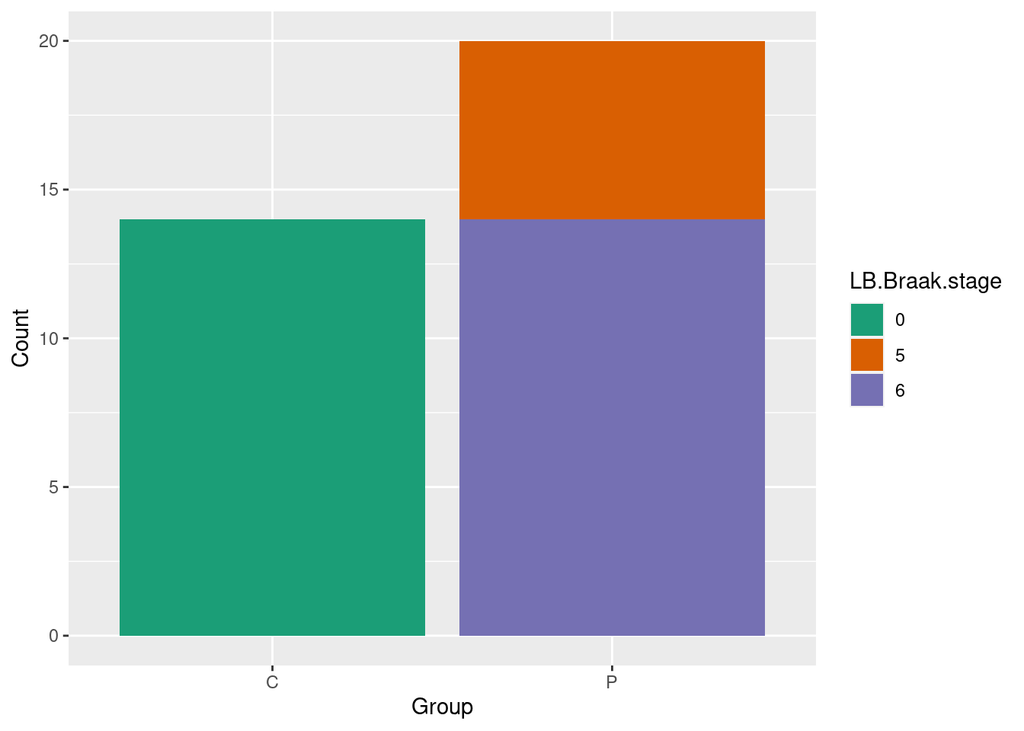

```r
df <- data.frame(table(donors$LB.Braak.stage, grp))
names(df) <- c("LB.Braak.stage", "Group", "Count")

ggplot(data=df, aes(x=Group, y=Count, fill=LB.Braak.stage)) +
  geom_bar(stat="identity") +
  scale_fill_brewer(palette = "Dark2")
```

Fisher’s exact test to compare groups:

```r
fisher.test(donors$LB.Braak.stage, grp)
```

```
##
##  Fisher's Exact Test for Count Data
##
## data:  donors$LB.Braak.stage and grp
## p-value = 1.437e-09
## alternative hypothesis: two.sided
```

### SN depigmentation

SN depigmentation only recorded for PD donors.

```r
df <- data.frame(table(donors$SN.depigmentation[grp=="P"]))
names(df) <- c("SN.depigmentation", "Count")
knitr::kable(df)
```

| SN.depigmentation | Count |
| --- | --- |
| 1 | 1 |
| 2 | 6 |
| 3 | 13 |

### Amyloid pathology

```r
knitr::kable(table(donors$Amyloid.pathology, grp))
```

|  | C | P |
| --- | --- | --- |
| 0 | 2 | 5 |
| 1 | 2 | 2 |
| 2 | 2 | 3 |
| 3 | 6 | 8 |
| 3.5 | 1 | 0 |
| 4 | 0 | 1 |
| 5 | 1 | 1 |

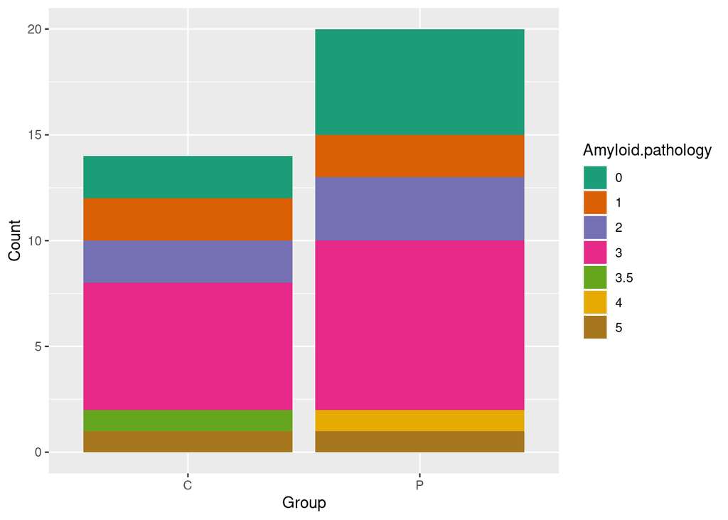

```r
df <- data.frame(table(donors$Amyloid.pathology, grp))
names(df) <- c("Amyloid.pathology", "Group", "Count")

ggplot(data=df, aes(x=Group, y=Count, fill=Amyloid.pathology)) +
  geom_bar(stat="identity") +
  scale_fill_brewer(palette = "Dark2")
```

Fisher’s exact test to compare groups:

```r
fisher.test(donors$Amyloid.pathology, grp)
```

```
##
##  Fisher's Exact Test for Count Data
##
## data:  donors$Amyloid.pathology and grp
## p-value = 0.9295
## alternative hypothesis: two.sided
```

### Tau pathology

```r
knitr::kable(table(donors$Tau.pathology, grp))
```

|  | C | P |
| --- | --- | --- |
| 0 | 2 | 0 |
| 1 | 3 | 5 |
| 2 | 8 | 5 |
| 3 | 1 | 10 |

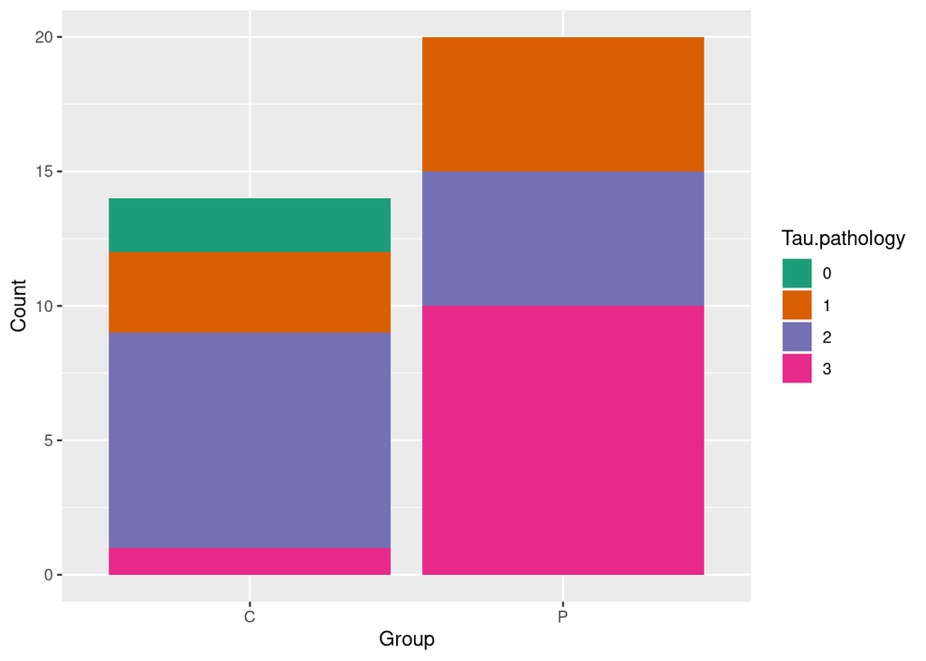

```r
df <- data.frame(table(donors$Tau.pathology, grp))
names(df) <- c("Tau.pathology", "Group", "Count")

ggplot(data=df, aes(x=Group, y=Count, fill=Tau.pathology)) +
  geom_bar(stat="identity") +
  scale_fill_brewer(palette = "Dark2")
```

Fisher’s exact test to compare groups:

```r
fisher.test(donors$Tau.pathology, grp)
```

```
##
##  Fisher's Exact Test for Count Data
##
## data:  donors$Tau.pathology and grp
## p-value = 0.01564
## alternative hypothesis: two.sided
```

### Vessel disease / CAA

```r
knitr::kable(table(donors$Vessel.disease...CAA, grp))
```

|  | C | P |
| --- | --- | --- |
| 0 | 12 | 10 |
| 1 | 5 | 5 |
| 2 | 2 | 2 |
| 3 | 1 | 3 |

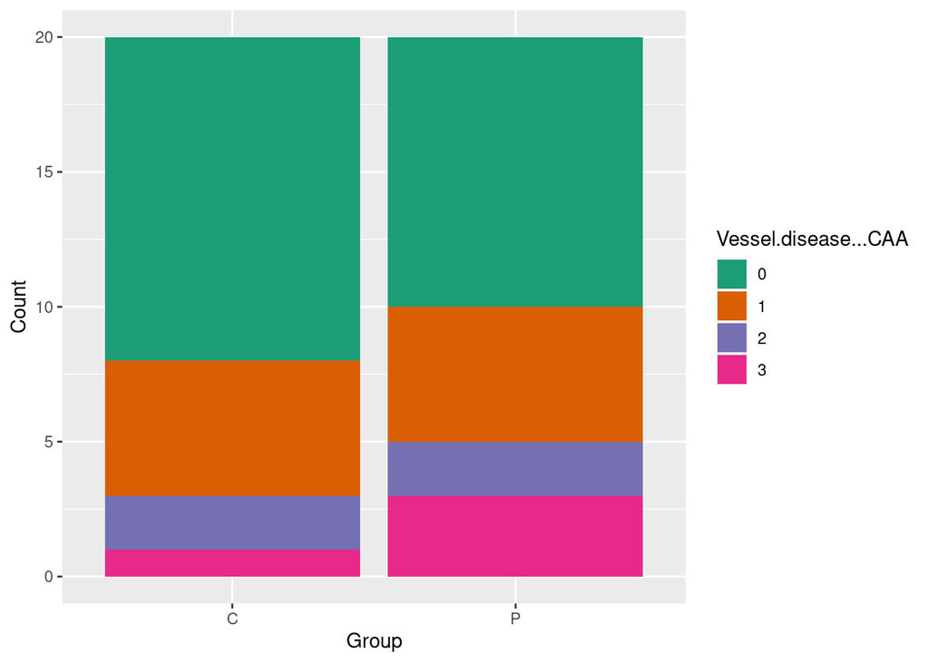

```r
df <- data.frame(table(donors$Vessel.disease...CAA, grp))
names(df) <- c("Vessel.disease...CAA", "Group", "Count")

ggplot(data=df, aes(x=Group, y=Count, fill=Vessel.disease...CAA)) +
  geom_bar(stat="identity") +
  scale_fill_brewer(palette = "Dark2")
```

Fisher’s exact test to compare groups:

```r
fisher.test(donors$Vessel.disease...CAA, grp)
```

```
##
##  Fisher's Exact Test for Count Data
##
## data:  donors$Vessel.disease...CAA and grp
## p-value = 0.8826
## alternative hypothesis: two.sided
```

## Continuous variables

### Age

Boxplot:

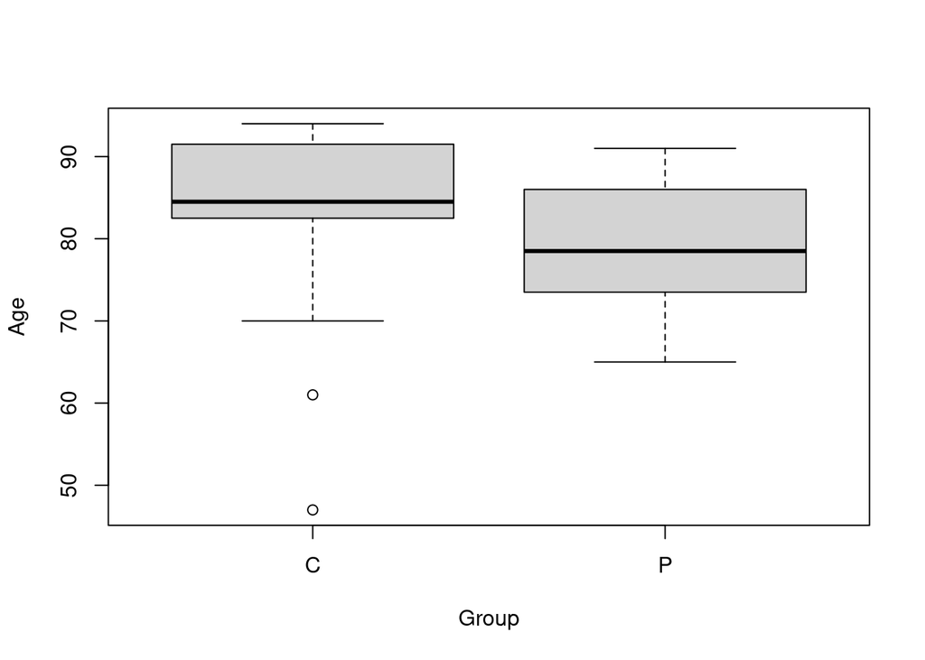

```r
boxplot(donors$Age ~ grp, ylab="Age", xlab="Group")
```

Quantile-Quantile plots:

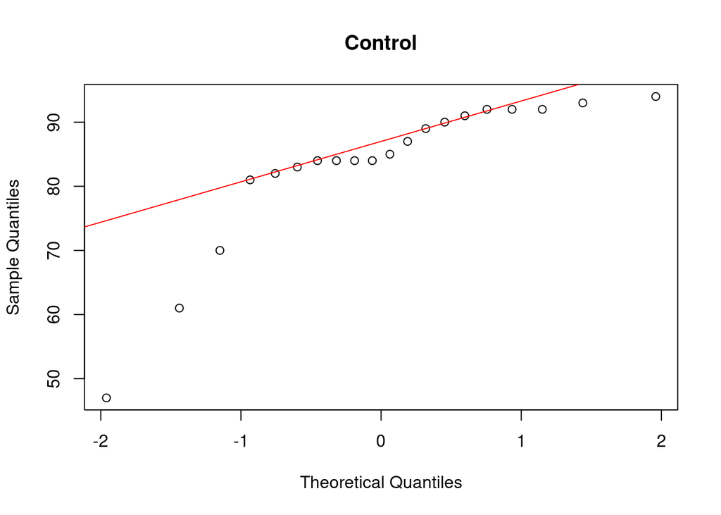

```r
qqnorm(donors$Age[grp=="C"], main="Control")
qqline(donors$Age[grp=="C"], col="red")
```

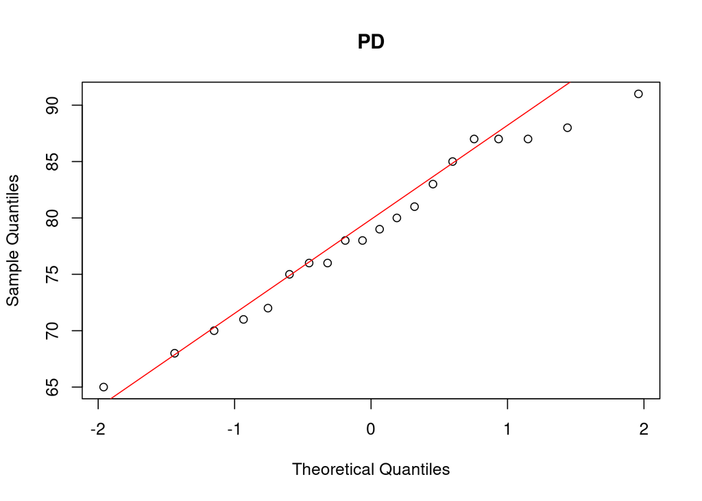

```r
qqnorm(donors$Age[grp=="P"], main="PD")
qqline(donors$Age[grp=="P"], col="red")
```

Shapiro-Wilk normality test applied by group:

```r
swPval(donors$Age[grp=="C"])
```

```
## [1] 0.00022136
```

```r
swPval(donors$Age[grp=="P"])
```

```
## [1] 0.7407061
```

As data for the control group do not follow a normal distribution, we will compare the two groups using the Wilcoxon Rank Sum test.

```r
wilcox.test(donors$Age ~grp)
```

```
##
##  Wilcoxon rank sum test with continuity correction
##
## data:  donors$Age by grp
## W = 286, p-value = 0.02055
## alternative hypothesis: true location shift is not equal to 0
```

### PD duration

PD duration by definition only is applicable to the Parkinson’s Disease group.

Boxplot:

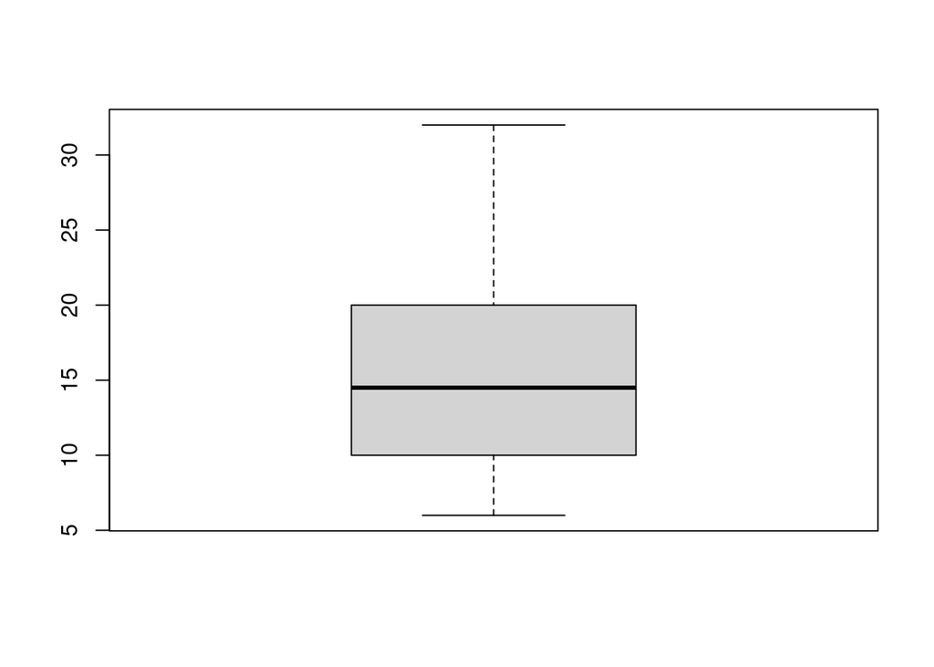

```r
boxplot(donors$PD.duration)
```

Quantile-Quantile plot:

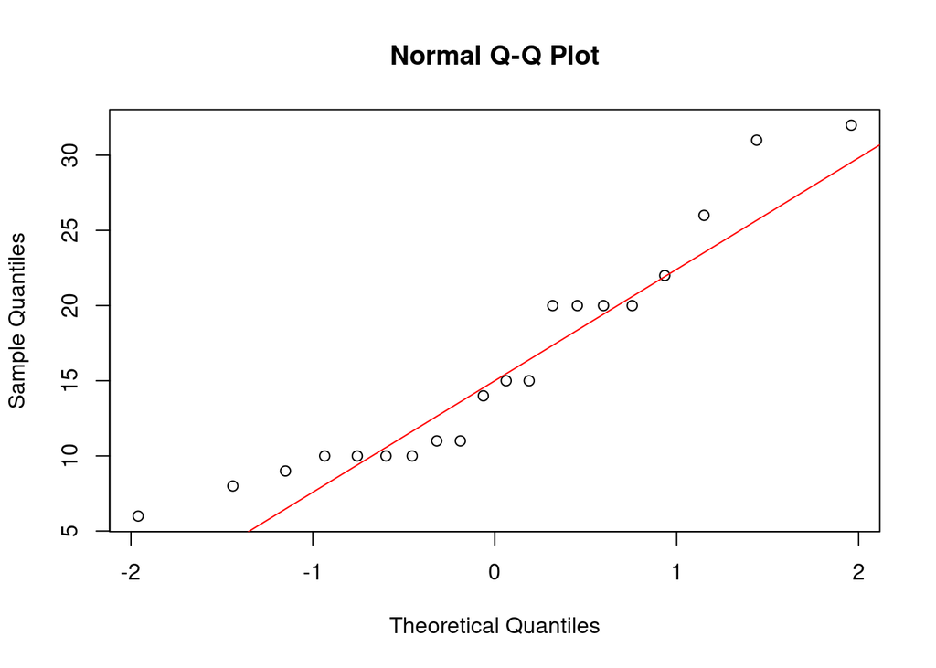

```r
qqnorm(donors$PD.duration)
qqline(donors$PD.duration, col="red")
```

Shapiro-Wilk normality test:

```r
swPval(donors$PD.duration)
```

```
## [1] 0.04521685
```

# Any evidence of correlation between variables?

Let’s use a scatterplot matrix to look for evidence of a relationship between pairs of ordinal and continuous variables. Key: blue squares = control; red circles = PD.

Scatterplot matrix of data from all donors.

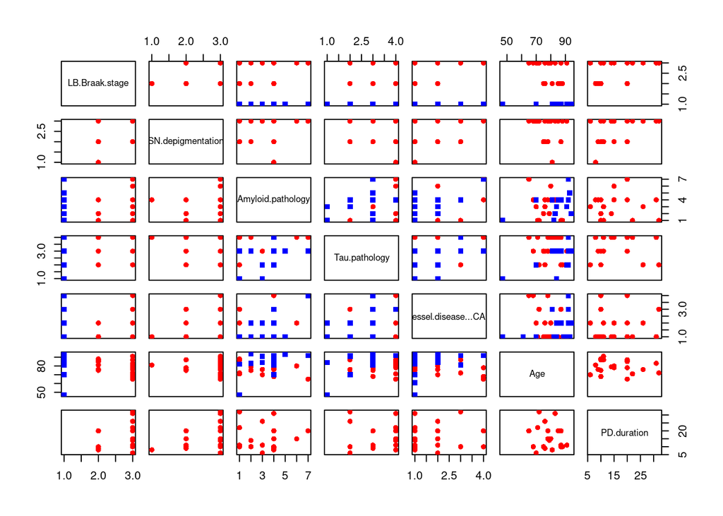

```r
pairs(donors[,c(11:17)], col=grpColor, pch=grpPch)
```

Scatterplot matrix of data from PD group.

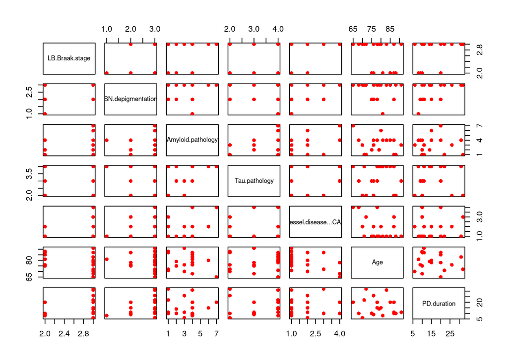

```r
pairs(donors[grp=="P",c(11:17)], col=grpColor[grp=="P"], pch=grpPch[grp=="P"])
```

Scatterplot matrix of data from control group.

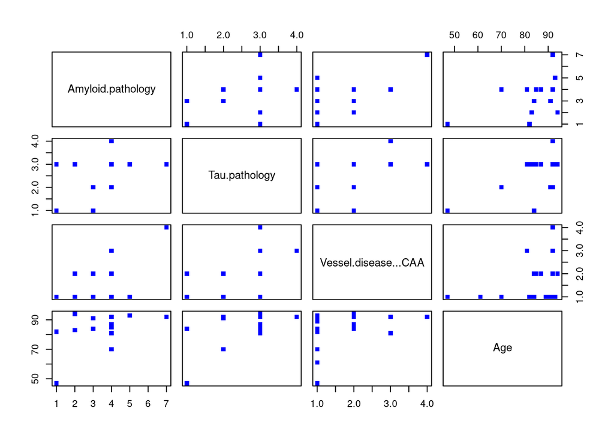

```r
pairs(donors[grp=="C",c(13:16)], col=grpColor[grp=="C"], pch=grpPch[grp=="C"])
```

Differences between the two groups are apparent, but no obvious correlation between any pair of variables.